# Data Science Project(Regression)

Group-04

2026-01-02

#### Dataset: Student Performance Factors

#### Source: Kaggle

#### Link: https://drive.google.com/uc?export=download&id=1IWA5bJ8t7s0pJKCGah4Fg4xVEFWS1SD5

#### Domain: Education

#### Objective: Predict student’s exam_scores using academic and behavioral features

### Load Required Packages

These libraries are used for: Data manipulation : dplyr, tidyr Data visualization : ggplot2, corrplot Categorical encoding : fastDummies

```r
packages <- c("ggplot2","dplyr","tidyr","fastDummies","corrplot")

for(pkg in packages){
  if(!require(pkg, character.only = TRUE)){
    install.packages(pkg, dependencies = TRUE)
    library(pkg, character.only = TRUE)
  }
}
```

# A.Data Collection

### Load dataset directly from URL to avoid local file dependency

This ensures the script runs on any machine without modification and Print dataset

```r
url <- "https://drive.google.com/uc?export=download&id=1IWA5bJ8t7s0pJKCGah4Fg4xVEFWS1SD5"
data <- read.csv(url, stringsAsFactors = FALSE)
head(data)
```

```
##   Hours_Studied Attendance Parental_Involvement Access_to_Resources
## 1            23         84                  Low                High
## 2            19         64                  Low              Medium
## 3            24         98               Medium              Medium
## 4            29         89                  Low              Medium
## 5            19         92               Medium              Medium
## 6            19         88               Medium              Medium
##   Extracurricular_Activities Sleep_Hours Previous_Scores Motivation_Level
## 1                         No           7              73              Low
## 2                         No           8              59              Low
## 3                        Yes           7              91           Medium
## 4                        Yes           8              98           Medium
## 5                        Yes           6              65           Medium
## 6                        Yes           8              89           Medium
##   Internet_Access Tutoring_Sessions Family_Income Teacher_Quality School_Type
```

[output cut: 20 more lines]

```r
cat("Dataset loaded successfully\n")
```

```
## Dataset loaded successfully
```

# B.Data understanding and Exploration

### To determine how many rows and columns in this dataset and Convert empty strings to NA for consistency

```r
data[data == ""] <- NA
cat("Rows:", nrow(data), " Columns:", ncol(data), "\n")
```

```
## Rows: 6607  Columns: 20
```

### Display dataset structure and summary statistics

To understand data dimensions, data types and summary statistics.

```r
dim(data)
```

```
## [1] 6607   20
```

```r
str(data)
```

```
## 'data.frame':    6607 obs. of  20 variables:
##  $ Hours_Studied             : int  23 19 24 29 19 19 29 25 17 23 ...
##  $ Attendance                : int  84 64 98 89 92 88 84 78 94 98 ...
##  $ Parental_Involvement      : chr  "Low" "Low" "Medium" "Low" ...
##  $ Access_to_Resources       : chr  "High" "Medium" "Medium" "Medium" ...
##  $ Extracurricular_Activities: chr  "No" "No" "Yes" "Yes" ...
##  $ Sleep_Hours               : int  7 8 7 8 6 8 7 6 6 8 ...
##  $ Previous_Scores           : int  73 59 91 98 65 89 68 50 80 71 ...
##  $ Motivation_Level          : chr  "Low" "Low" "Medium" "Medium" ...
##  $ Internet_Access           : chr  "Yes" "Yes" "Yes" "Yes" ...
##  $ Tutoring_Sessions         : int  0 2 2 1 3 3 1 1 0 0 ...
##  $ Family_Income             : chr  "Low" "Medium" "Medium" "Medium" ...
##  $ Teacher_Quality           : chr  "Medium" "Medium" "Medium" "Medium" ...
##  $ School_Type               : chr  "Public" "Public" "Public" "Public" ...
##  $ Peer_Influence            : chr  "Positive" "Negative" "Neutral" "Negative" ...
##  $ Physical_Activity         : int  3 4 4 4 4 3 2 2 1 5 ...
##  $ Learning_Disabilities     : chr  "No" "No" "No" "No" ...
##  $ Parental_Education_Level  : chr  "High School" "College" "Postgraduate" "High School" ...
##  $ Distance_from_Home        : chr  "Near" "Moderate" "Near" "Moderate" ...
##  $ Gender                    : chr  "Male" "Female" "Male" "Male" ...
##  $ Exam_Score                : int  67 61 74 71 70 71 67 66 69 72 ...
```

```r
summary(data)
```

```
##  Hours_Studied     Attendance     Parental_Involvement Access_to_Resources
##  Min.   : 1.00   Min.   : 60.00   Length:6607          Length:6607
##  1st Qu.:16.00   1st Qu.: 70.00   Class :character     Class :character
##  Median :20.00   Median : 80.00   Mode  :character     Mode  :character
##  Mean   :19.98   Mean   : 79.98
##  3rd Qu.:24.00   3rd Qu.: 90.00
##  Max.   :44.00   Max.   :100.00
##  Extracurricular_Activities  Sleep_Hours     Previous_Scores
##  Length:6607                Min.   : 4.000   Min.   : 50.00
##  Class :character           1st Qu.: 6.000   1st Qu.: 63.00
##  Mode  :character           Median : 7.000   Median : 75.00
##                             Mean   : 7.029   Mean   : 75.07
##                             3rd Qu.: 8.000   3rd Qu.: 88.00
##                             Max.   :10.000   Max.   :100.00
##  Motivation_Level   Internet_Access    Tutoring_Sessions Family_Income
##  Length:6607        Length:6607        Min.   :0.000     Length:6607
##  Class :character   Class :character   1st Qu.:1.000     Class :character
##  Mode  :character   Mode  :character   Median :1.000     Mode  :character
##                                        Mean   :1.494
##                                        3rd Qu.:2.000
##                                        Max.   :8.000
##  Teacher_Quality    School_Type        Peer_Influence     Physical_Activity
##  Length:6607        Length:6607        Length:6607        Min.   :0.000
##  Class :character   Class :character   Class :character   1st Qu.:2.000
##  Mode  :character   Mode  :character   Mode  :character   Median :3.000
##                                                           Mean   :2.968
##                                                           3rd Qu.:4.000
##                                                           Max.   :6.000
##  Learning_Disabilities Parental_Education_Level Distance_from_Home
##  Length:6607           Length:6607              Length:6607
##  Class :character      Class :character         Class :character
##  Mode  :character      Mode  :character         Mode  :character
##
##
##
##     Gender            Exam_Score
##  Length:6607        Min.   : 55.00
##  Class :character   1st Qu.: 65.00
##  Mode  :character   Median : 67.00
##                     Mean   : 67.24
##                     3rd Qu.: 69.00
##                     Max.   :101.00
```

### Identify numerical and categorical features

```r
num_cols <- sapply(data, is.numeric)

cat_cols <- sapply(data, is.character)

cat("\nNumeric Features:\n")
```

```
##
## Numeric Features:
```

```r
print(names(data)[num_cols])
```

```
## [1] "Hours_Studied"     "Attendance"        "Sleep_Hours"
## [4] "Previous_Scores"   "Tutoring_Sessions" "Physical_Activity"
## [7] "Exam_Score"
```

```r
cat("\nCategorical Features:\n")
```

```
##
## Categorical Features:
```

```r
print(names(data)[cat_cols])
```

```
##  [1] "Parental_Involvement"       "Access_to_Resources"
##  [3] "Extracurricular_Activities" "Motivation_Level"
##  [5] "Internet_Access"            "Family_Income"
##  [7] "Teacher_Quality"            "School_Type"
##  [9] "Peer_Influence"             "Learning_Disabilities"
## [11] "Parental_Education_Level"   "Distance_from_Home"
## [13] "Gender"
```

### Identify Target Variable

The target variable is the dependent variable that we want to predict. “Exam_Score” represents students’ academic performance.Since it is a continuous numerical variable, this problem is formulated as a regression task.

```r
target <- colnames(data)[ncol(data)]
cat("Target Variable:", target, "\n")
```

```
## Target Variable: Exam_Score
```

### Exploratory Data Analysis (EDA)

Purpose of EDA: 1. Understand the distribution of the target variable.. Analyze relationships between predictors and target.. Detect correlations and potential multicollinearity.. Examine categorical feature distributions

#### Identify Numerical Predictors (excluding target variable)

```r
# Exclude the target variable from the numeric columns (so it won't be treated as a predictor)
num_cols[target] <- FALSE

# Get the names of numeric columns that will be used as predictors
num_predictors <- names(data)[num_cols]
```

### Target Variable Distribution Analysis (Histogram)

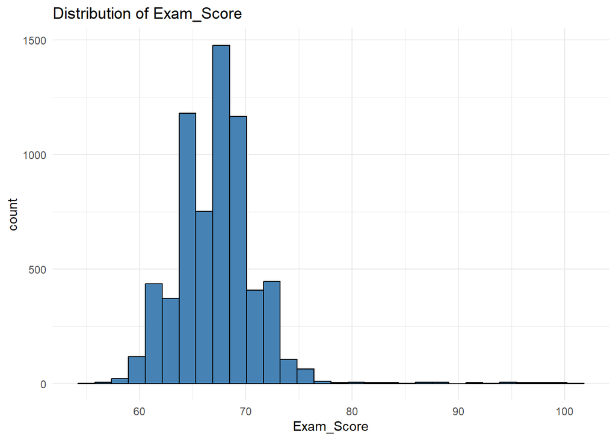

```r
ggplot(data, aes(.data[[target]])) +

  geom_histogram(bins = 30, fill = "steelblue", color = "black") +

  theme_minimal() +

  ggtitle("Distribution of Exam_Score")
```

### Boxplot

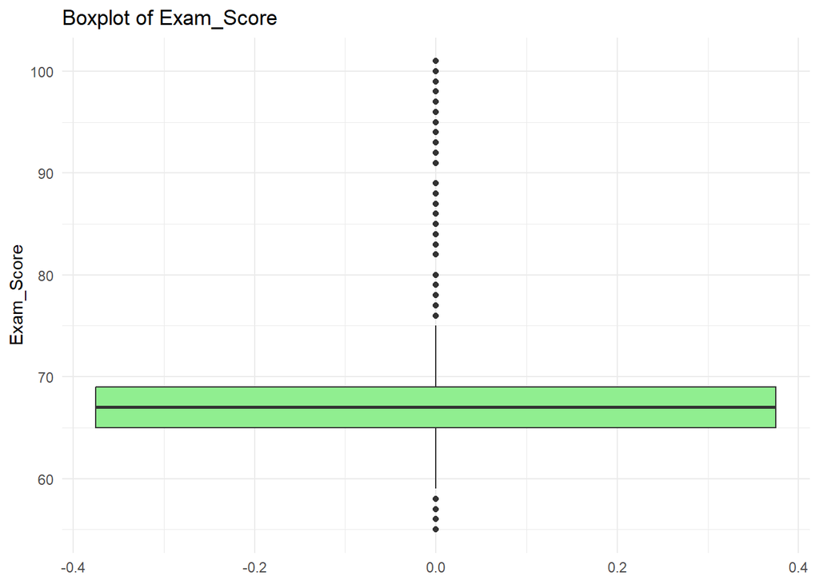

```r
ggplot(data, aes(y = .data[[target]])) +
  geom_boxplot(fill = "lightgreen") +
  theme_minimal() +

  ggtitle("Boxplot of Exam_Score")
```

### Scatter plots

Numerical Features vs Target 1.Examine linear relationships between predictors and target 2.Validate the assumption of linearity 3.Identify trends and variability

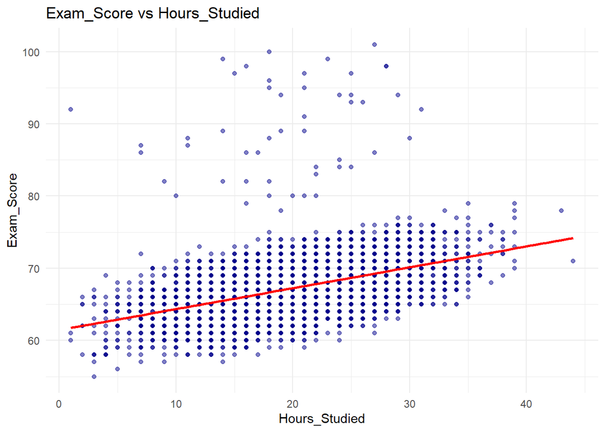

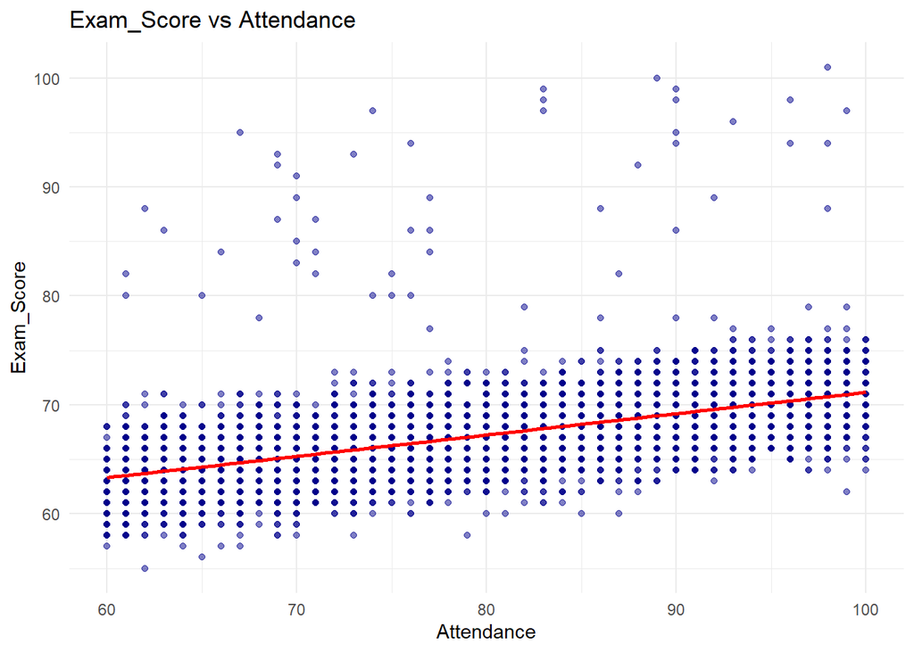

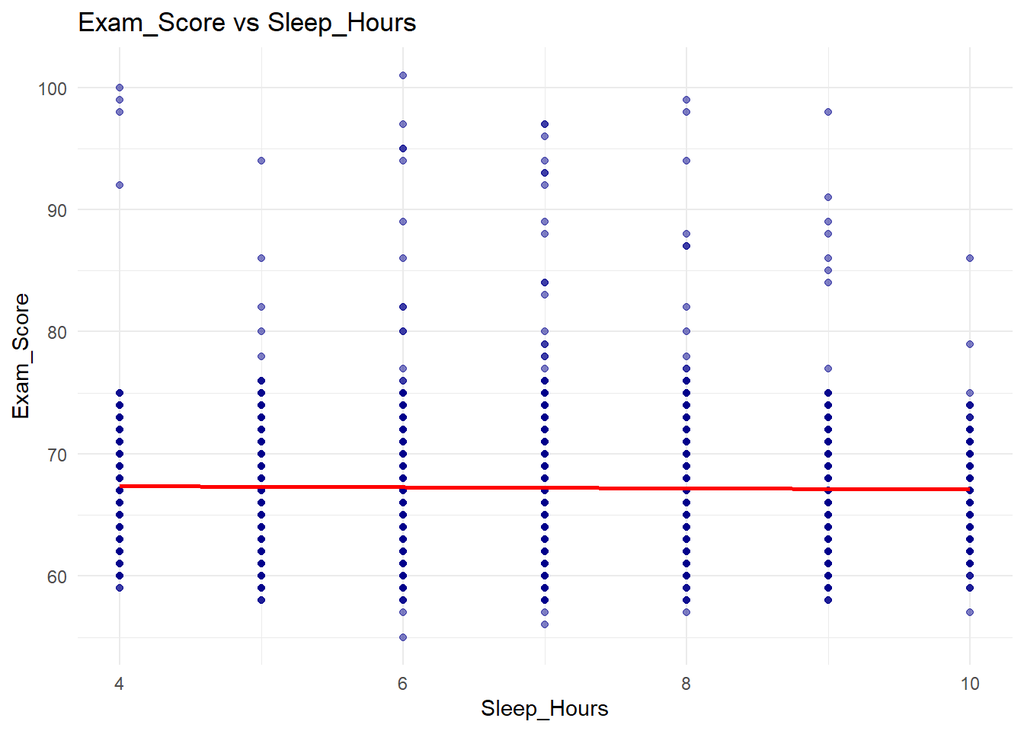

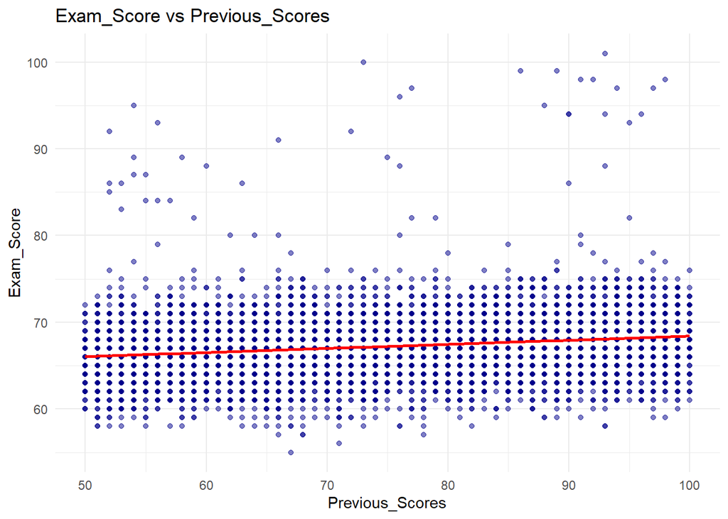

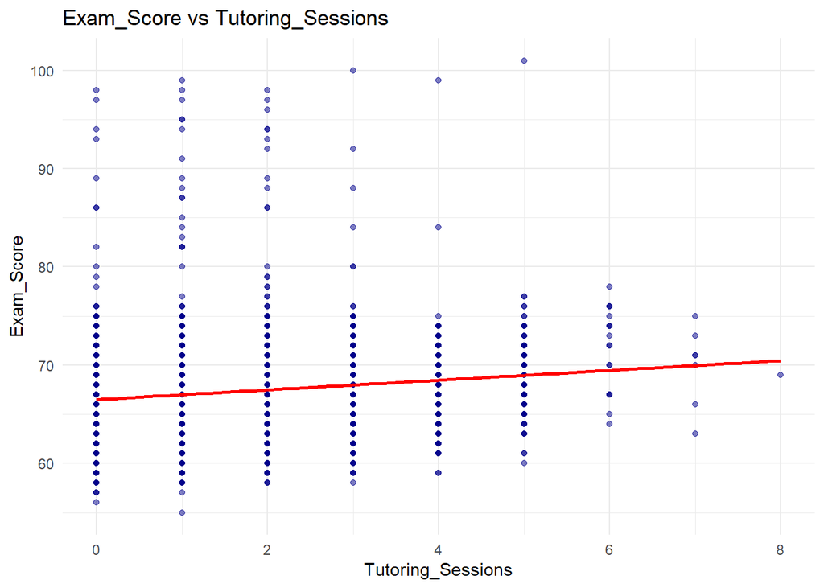

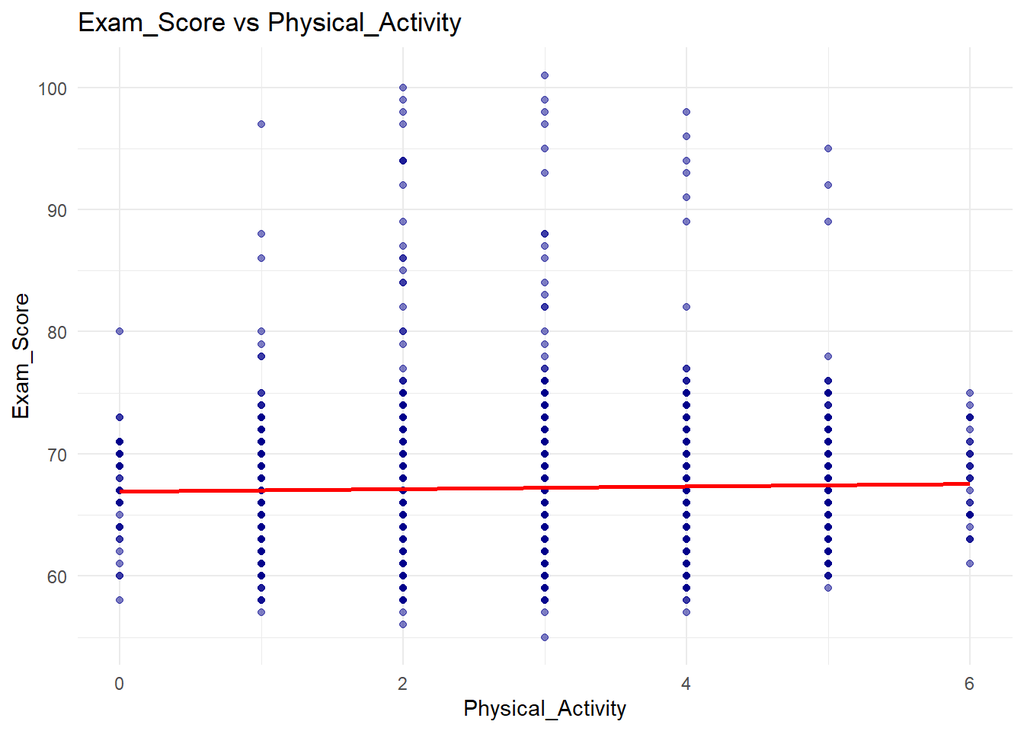

```r
# Loop through each numeric predictor to visualize its relationship with the target
for(col in num_predictors){
  p <- ggplot(data, aes(x = .data[[col]], y = .data[[target]])) +
    geom_point(alpha = 0.5, color = "darkblue") +
    geom_smooth(method = "lm", se = FALSE, color = "red") +
    theme_minimal() +
    ggtitle(paste("Exam_Score vs", col))
  print(p)
}
```

### Correlation Matrix

Helps detect multicollinearity among numerical predictors.

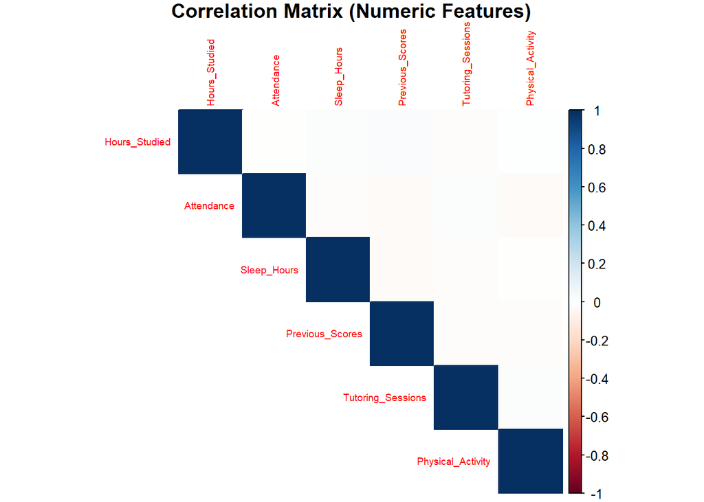

```r
cor_matrix <- cor(data[, num_predictors], use = "pairwise.complete.obs")

corrplot(
  cor_matrix,
  method = "color",
  type = "upper",
  tl.cex = 0.6,
  title = "Correlation Matrix (Numeric Features)",
  mar = c(0,0,1,0)
)
```

### Bar Plots

Categorical variables are visualized using bar plots to: 1.Understand class frequency 2.Detect class imbalance 3.Decide encoding strategy

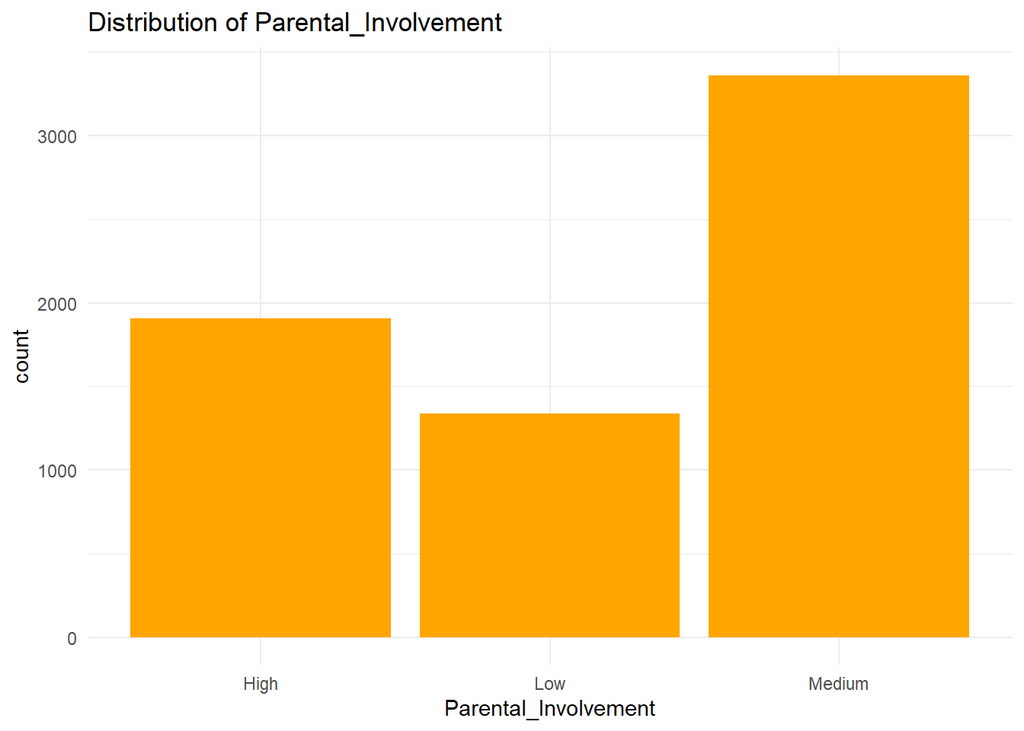

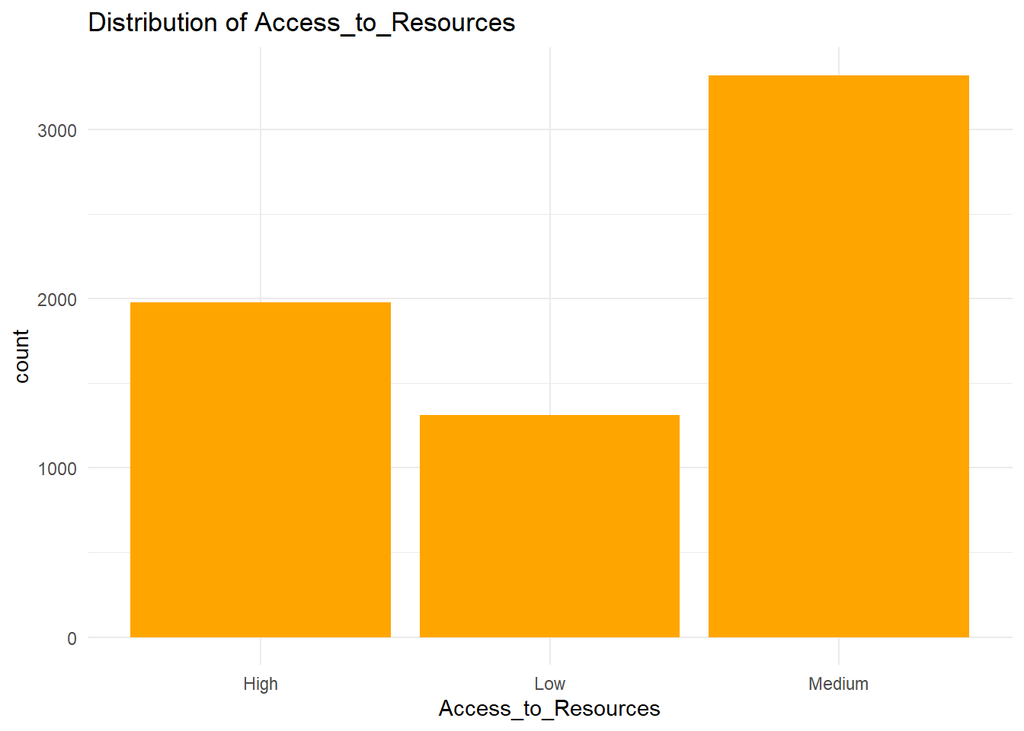

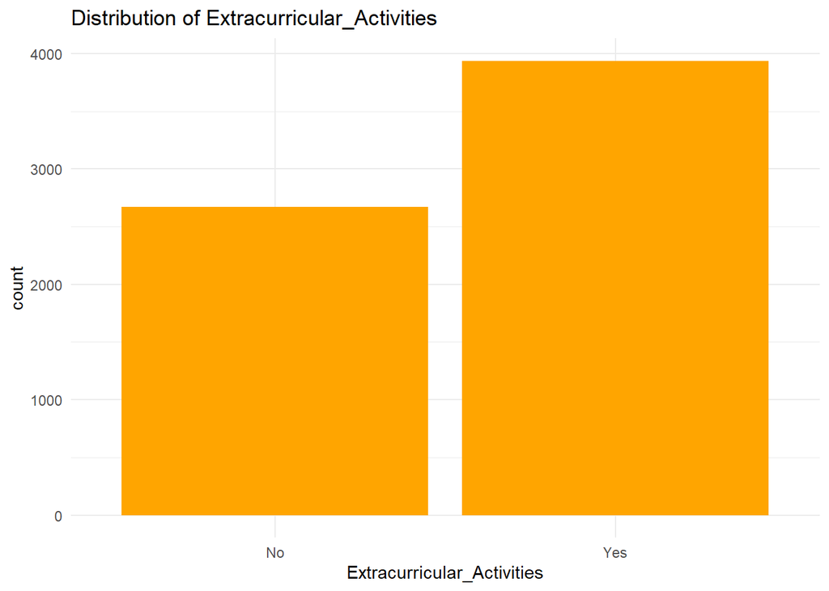

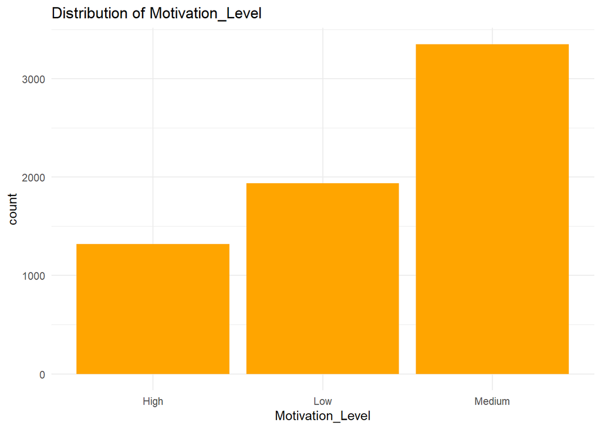

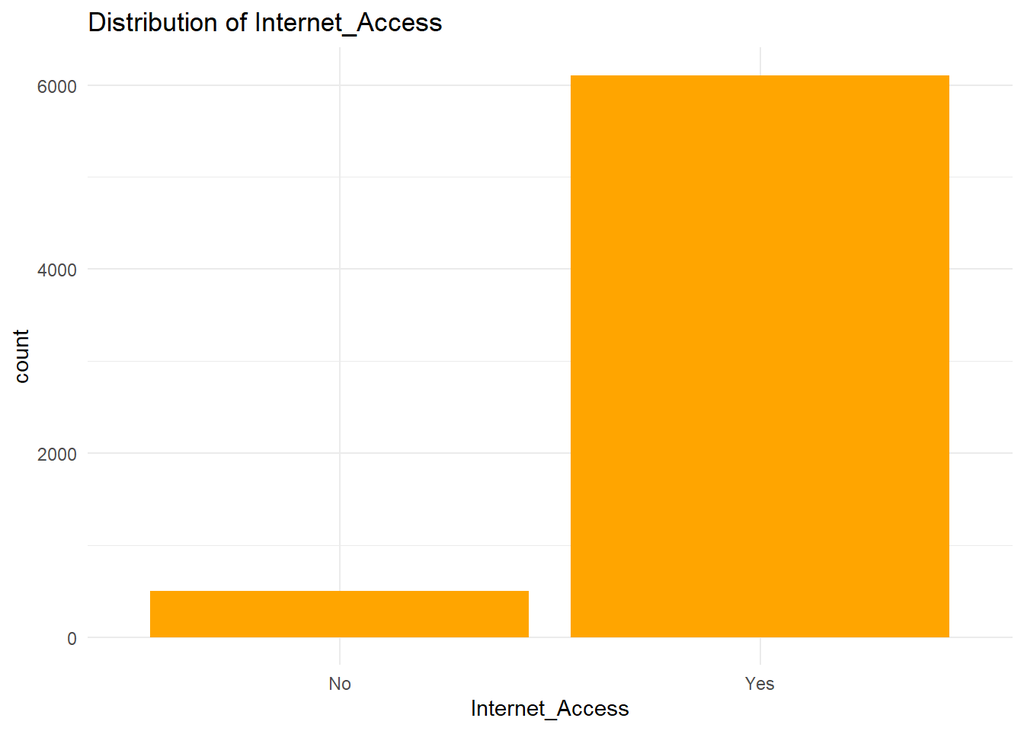

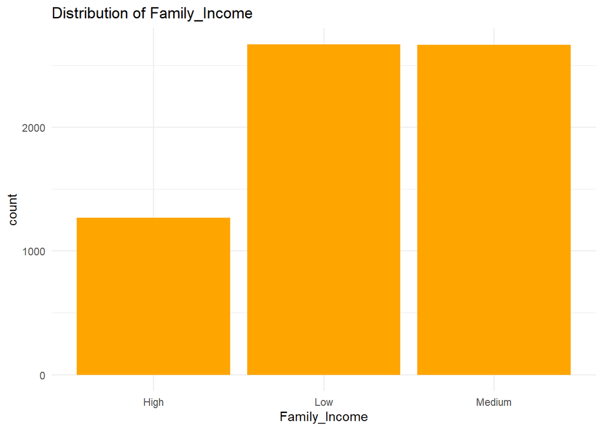

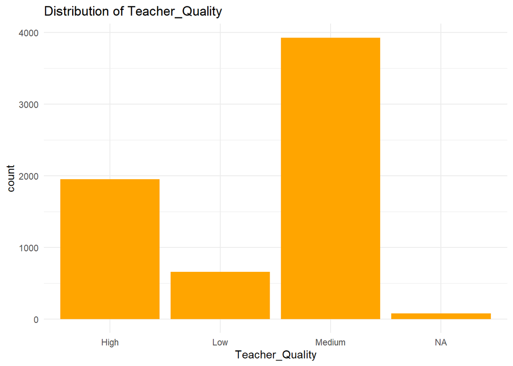

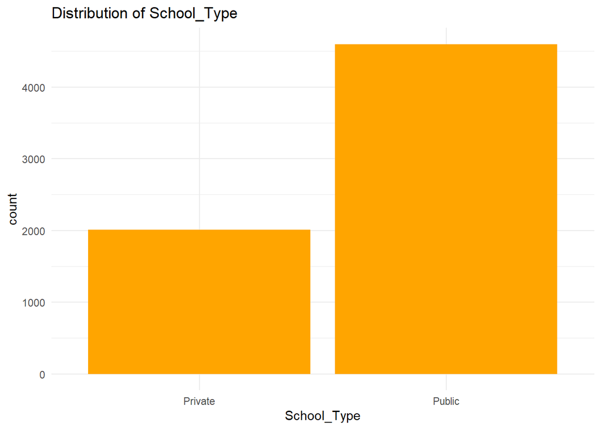

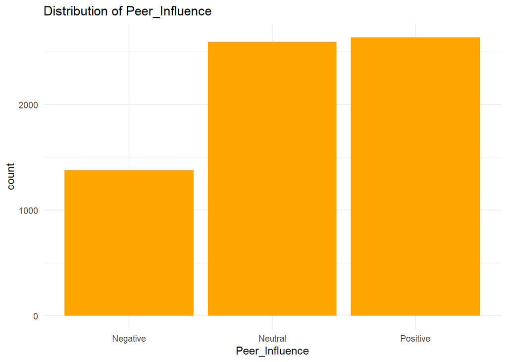

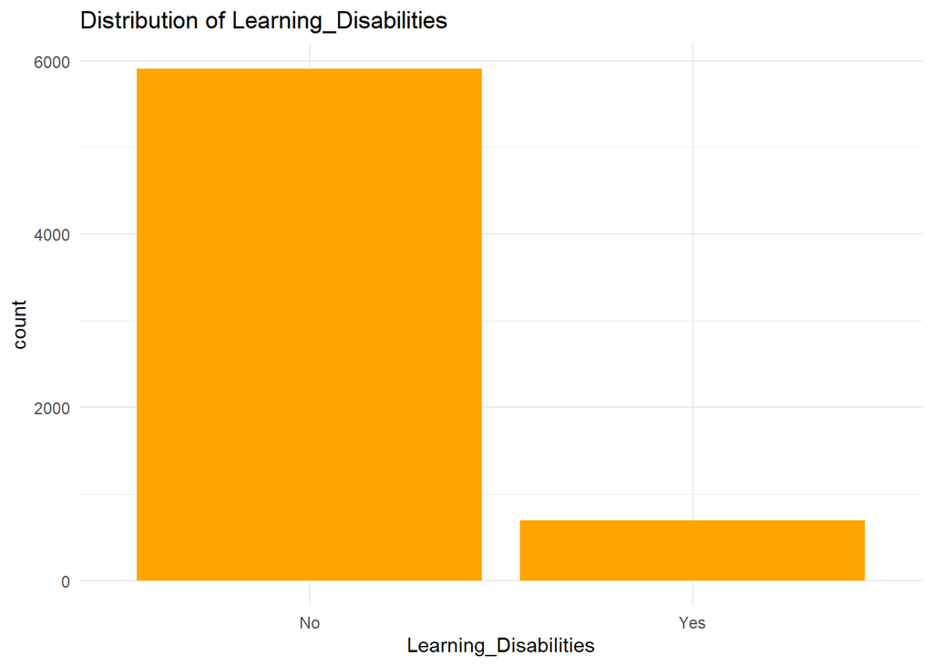

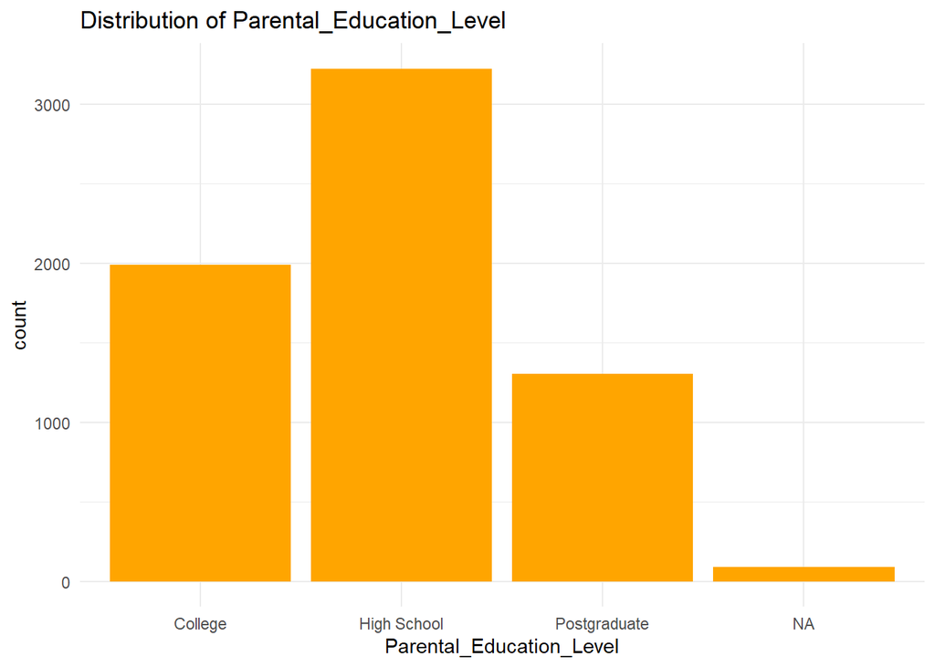

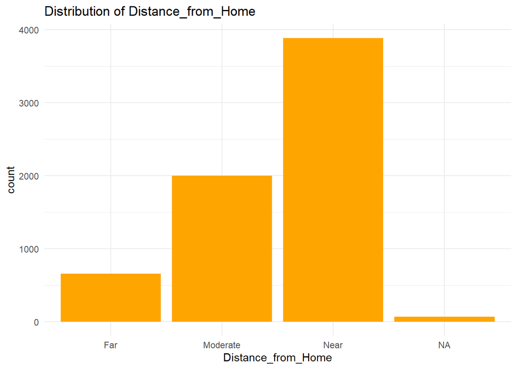

[1 more figures not shown]

```r
cat_cols[target] <- FALSE
cat_predictors <- names(data)[cat_cols]

for(col in cat_predictors){
  p <- ggplot(data, aes(x = .data[[col]])) +
    geom_bar(fill = "orange") +
    theme_minimal() +
    ggtitle(paste("Distribution of", col))
  print(p)
}
```

# C.Data Preprocessing

### Missing Value Handling

Numerical features → Median (robust to outliers) Categorical features → Mode (most frequent value)

```r
for(col in names(data)[num_cols]){
  data[[col]][is.na(data[[col]])] <- median(data[[col]], na.rm = TRUE)
}

get_mode <- function(x){
  ux <- unique(x)
  ux[which.max(tabulate(match(x, ux)))]
}

for(col in names(data)[cat_cols]){
  data[[col]][is.na(data[[col]])] <- get_mode(data[[col]])
}
```

### Remove Duplicate Rows

```r
data <- data[!duplicated(data), ]
```

### Outlier Handling (IQR Capping)

Outliers can heavily influence regression coefficients. IQR-based capping reduces extreme values without removing data points.

```r
numerical_vars <- setdiff(names(data)[sapply(data, is.numeric)], target)

cap_outliers_iqr <- function(x){
  Q1 <- quantile(x, 0.25)
  Q3 <- quantile(x, 0.75)
  IQR <- Q3 - Q1

  lower <- Q1 - 1.5 * IQR
  upper <- Q3 + 1.5 * IQR

  x[x < lower] <- lower
  x[x > upper] <- upper

  return(x)
}

for(var in numerical_vars){
  data[[var]] <- cap_outliers_iqr(data[[var]])
}
```

### Encode Categorical Variables

```r
data <- fastDummies::dummy_cols(
  data,
  select_columns = cat_predictors,
  remove_first_dummy = TRUE,
  remove_selected_columns = TRUE
)
```

### Feature Engineering

Creating new features to improve model performance.

```r
data$log_Previous_Scores <- log(data$Previous_Scores + 1)
data$Hours_Attendance <- data$Hours_Studied * data$Attendance
predictors <- setdiff(names(data), target)
```

### Feature Scaling

Standardization ensures all predictors are on the same scale.

```r
data[, predictors] <- scale(data[, predictors])
```

# D.Modeling

80% training, 20% testing

```r
# Set a seed for reproducibility so that the random sampling is consistent
set.seed(123)

# Randomly select 80% of the row indices for the training set
index <- sample(seq_len(nrow(data)), size = 0.8 * nrow(data))

train <- data[index, ]
test  <- data[-index, ]
```

### Model Summary

Multiple Linear Regression is used because the target variable is continuous.

```r
model <- lm(Exam_Score ~ ., data = train)

summary(model)
```

```
##
## Call:
## lm(formula = Exam_Score ~ ., data = train)
##
## Residuals:
##     Min      1Q  Median      3Q     Max
## -1.7607 -0.4527 -0.1839  0.0954 29.7077
##
## Coefficients:
##                                         Estimate Std. Error  t value Pr(>|t|)
## (Intercept)                            67.245164   0.028693 2343.568  < 2e-16
## Hours_Studied                           1.358551   0.201178    6.753 1.61e-11
## Attendance                              2.093804   0.100108   20.915  < 2e-16
## Sleep_Hours                             0.002321   0.028919    0.080 0.936047
## Previous_Scores                         1.205588   0.328477    3.670 0.000245
## Tutoring_Sessions                       0.615529   0.028800   21.373  < 2e-16
## Physical_Activity                       0.200631   0.028739    6.981 3.29e-12
## Parental_Involvement_Low               -0.793924   0.033669  -23.581  < 2e-16
## Parental_Involvement_Medium            -0.551608   0.033386  -16.522  < 2e-16
## Access_to_Resources_Low                -0.828698   0.033120  -25.021  < 2e-16
## Access_to_Resources_Medium             -0.490036   0.033161  -14.777  < 2e-16
## Extracurricular_Activities_Yes          0.281313   0.028711    9.798  < 2e-16
## Motivation_Level_Low                   -0.487049   0.037658  -12.934  < 2e-16
## Motivation_Level_Medium                -0.262273   0.037874   -6.925 4.89e-12
## Internet_Access_Yes                     0.249221   0.028777    8.660  < 2e-16
## Family_Income_Low                      -0.541066   0.039158  -13.818  < 2e-16
## Family_Income_Medium                   -0.292296   0.039066   -7.482 8.52e-14
## Teacher_Quality_Low                    -0.335609   0.031128  -10.782  < 2e-16
## Teacher_Quality_Medium                 -0.290066   0.031547   -9.195  < 2e-16
## School_Type_Public                      0.007231   0.028803    0.251 0.801791
## Peer_Influence_Neutral                  0.241670   0.038142    6.336 2.55e-10
## Peer_Influence_Positive                 0.497877   0.038028   13.092  < 2e-16
## Learning_Disabilities_Yes              -0.254075   0.028781   -8.828  < 2e-16
## `Parental_Education_Level_High School` -0.241220   0.033101   -7.287 3.63e-13
## Parental_Education_Level_Postgraduate   0.191223   0.033033    5.789 7.50e-09
## Distance_from_Home_Moderate             0.185695   0.048559    3.824 0.000133
## Distance_from_Home_Near                 0.442274   0.048579    9.104  < 2e-16
## Gender_Male                            -0.024408   0.028683   -0.851 0.394831
## log_Previous_Scores                    -0.520309   0.328348   -1.585 0.113111
## Hours_Attendance                        0.448401   0.222124    2.019 0.043569
```

[output cut: 22 more lines]

```
## Peer_Influence_Positive                ***
## Learning_Disabilities_Yes              ***
## `Parental_Education_Level_High School` ***
## Parental_Education_Level_Postgraduate  ***
## Distance_from_Home_Moderate            ***
## Distance_from_Home_Near                ***
## Gender_Male
## log_Previous_Scores
## Hours_Attendance                       *
## ---
## Signif. codes:  0 '***' 0.001 '**' 0.01 '*' 0.05 '.' 0.1 ' ' 1
##
## Residual standard error: 2.085 on 5255 degrees of freedom
## Multiple R-squared:  0.7172, Adjusted R-squared:  0.7157
## F-statistic: 459.7 on 29 and 5255 DF,  p-value: < 2.2e-16
```

# E.Evaluation

```r
pred   <- predict(model, test)

actual <- test$Exam_Score

RMSE <- sqrt(mean((pred - actual)^2))

MAE  <- mean(abs(pred - actual))

R2   <- cor(pred, actual)^2


cat("RMSE:", RMSE, "\n")
```

```
## RMSE: 1.839819
```

```r
cat("MAE :", MAE, "\n")
```

```
## MAE : 0.4753267
```

```r
cat("R²  :", R2, "\n")
```

```
## R²  : 0.7672245
```

### Feature Importance

Regression coefficients indicate the impact of each predictor on Exam_Score.

```r
coef_df <- data.frame(
  Feature = names(coef(model))[-1],
  Coefficient = coef(model)[-1]
) %>%
  arrange(desc(abs(Coefficient)))

head(coef_df, 10)
```

```
##                                                 Feature Coefficient
## Attendance                                   Attendance   2.0938037
## Hours_Studied                             Hours_Studied   1.3585508
## Previous_Scores                         Previous_Scores   1.2055883
## Access_to_Resources_Low         Access_to_Resources_Low  -0.8286985
## Parental_Involvement_Low       Parental_Involvement_Low  -0.7939238
## Tutoring_Sessions                     Tutoring_Sessions   0.6155292
## Parental_Involvement_Medium Parental_Involvement_Medium  -0.5516077
## Family_Income_Low                     Family_Income_Low  -0.5410660
## log_Previous_Scores                 log_Previous_Scores  -0.5203085
## Peer_Influence_Positive         Peer_Influence_Positive   0.4978774
```

### Actual vs Predicted Visualization

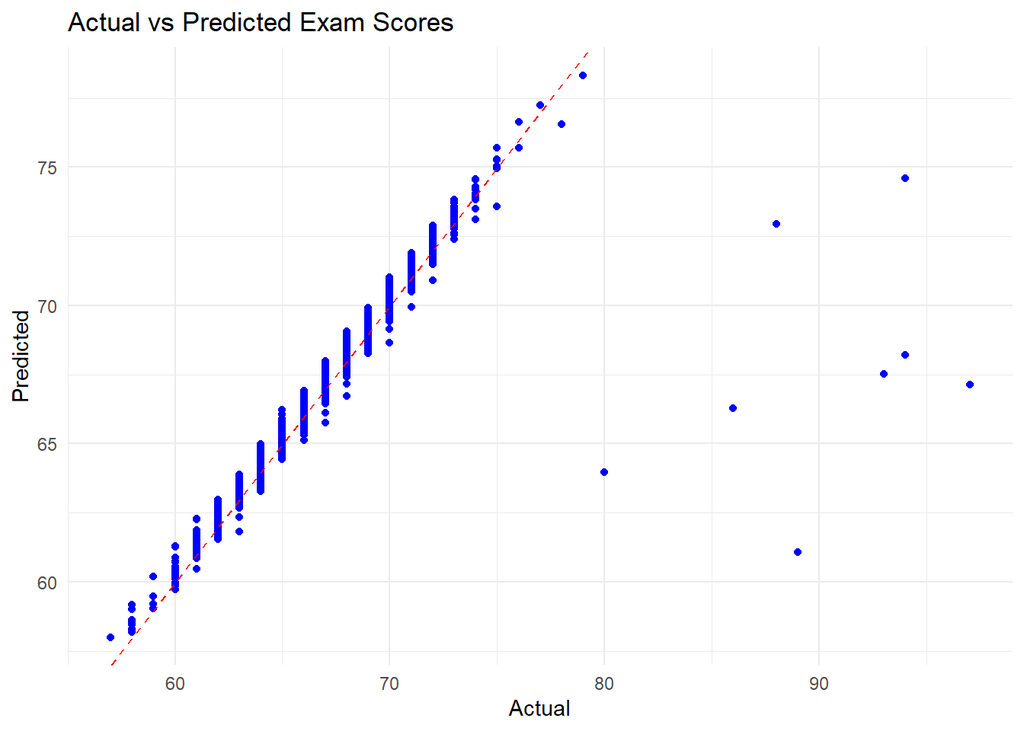

```r
# Create a scatter plot to compare actual and predicted Exam_Score values
ggplot(data.frame(Actual = actual, Predicted = pred),
       aes(Actual, Predicted)) +
  geom_point(color = "blue") +
  geom_abline(slope = 1, intercept = 0,
              linetype = "dashed", color = "red") +
  theme_minimal() +
  ggtitle("Actual vs Predicted Exam Scores")
```

### Sample Prediction (5 Students)

```r
sample_test <- head(test, 5)

sample_pred <- predict(model, sample_test)


sample_results <- data.frame(
  Student_ID = rownames(sample_test),
  Actual     = sample_test$Exam_Score,
  Predicted  = sample_pred
)

print(sample_results)
```

```
##    Student_ID Actual Predicted
## 3           3     74  74.30561
## 4           4     71  71.01037
## 7           7     67  67.24851
## 8           8     66  66.69903
## 10         10     72  72.29956
```

### Visualization: Actual vs Predicted for 5 students

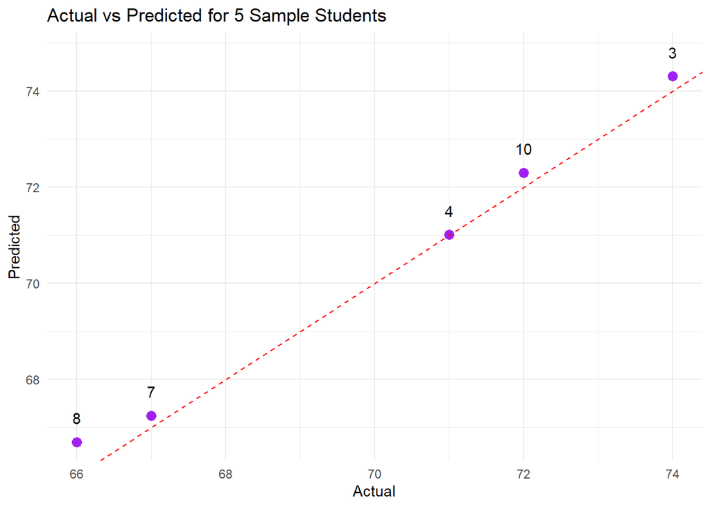

```r
ggplot(sample_results, aes(x = Actual, y = Predicted, label = Student_ID)) +
  geom_point(color = "purple", size = 3) +
  geom_text(nudge_y = 0.5) +
  geom_abline(slope = 1, intercept = 0, linetype = "dashed", color = "red") +
  theme_minimal() +
  ggtitle("Actual vs Predicted for 5 Sample Students")
```